# RV預測project

### Part 2 : 資料整理

### 調整除權息、計算實際波動度&隱含波動度

# 歡迎來到我們的RV預測Project第二集!!

### 我們會將Part 1準備好的原始資料進行轉換，以獲得我們DL模型所需的訓練資料。

在我們取得了**大盤的5秒日內資料**、**選擇權每日的收盤價資料**以及**每日的無風險利率**，我們將需要對資料進行轉換與處理。

1. 將大盤的5秒日內資料**還原除權息之後**，轉換成每日的**實質波動度(realized_volatility, RV)**
2. 為了計算**隱含波動度(Implied volatility, IV)**，需要知道當日的收盤價、無風險利率、選擇權的到期時間  
   如同我們的論文假設，為了減少到期日不對稱的狀況，在每一個交易日中，我們將選擇該日中，最快到期的option做IV的估計。

## 還原大盤除權息

```python
import pandas as pd
import sqlite3
import numpy as np
```

```python
# 台灣點數公司提供
url = 'https://www.taiwanindex.com.tw/index/history?id=DIVP&start=20160101'
```

```python
df = pd.read_html(url)
```

```python
div_df = df[0][::-1]
div_df.reset_index(drop = True, inplace = True)
div_df
```

|  | 日期 | 股利點數 | 漲跌點數 | 個股影響點數 |
| --- | --- | --- | --- | --- |
| 0 | 2016/05/03 | 0.00 | 0.00 | - |
| 1 | 2016/05/04 | 0.06 | 0.06 | 明細 |
| 2 | 2016/05/05 | 0.06 | 0.00 | - |
| 3 | 2016/05/06 | 0.40 | 0.34 | 明細 |
| 4 | 2016/05/09 | 0.40 | 0.00 | - |
| ... | ... | ... | ... | ... |
| 1272 | 2022/08/30 | 643.37 | 1.55 | 明細 |
| 1273 | 2022/08/31 | 643.47 | 0.10 | 明細 |
| 1274 | 2022/09/01 | 644.03 | 0.56 | 明細 |
| 1275 | 2022/09/02 | 644.12 | 0.09 | 明細 |
| 1276 | 2022/09/05 | 646.97 | 2.85 | 明細 |

1277 rows × 4 columns

```python
# 將日期做格式修改
div_df['日期'] = div_df['日期'].str.replace('/','')
div_df
```

|  | 日期 | 股利點數 | 漲跌點數 | 個股影響點數 |
| --- | --- | --- | --- | --- |
| 0 | 20160503 | 0.00 | 0.00 | - |
| 1 | 20160504 | 0.06 | 0.06 | 明細 |
| 2 | 20160505 | 0.06 | 0.00 | - |
| 3 | 20160506 | 0.40 | 0.34 | 明細 |
| 4 | 20160509 | 0.40 | 0.00 | - |
| ... | ... | ... | ... | ... |
| 1272 | 20220830 | 643.37 | 1.55 | 明細 |
| 1273 | 20220831 | 643.47 | 0.10 | 明細 |
| 1274 | 20220901 | 644.03 | 0.56 | 明細 |
| 1275 | 20220902 | 644.12 | 0.09 | 明細 |
| 1276 | 20220905 | 646.97 | 2.85 | 明細 |

1277 rows × 4 columns

```python
# 讀取在Part 1 建立好的大盤5秒資料
db_path = '/Users/robert/Documents/碩士畢業論文/Code_and_db/RV_predict_project.db'
conn = sqlite3.connect(db_path, timeout = 20)
# 從db中讀取全部資料
df = pd.read_sql_query("SELECT * FROM TAIEX_index;", conn)
df['發行量加權股價指數'] = df['發行量加權股價指數'].str.replace(',','').astype(float)
```

```python
index_df = df.copy()
# 因為除權息的資料最早只有到2016年，故我們只保留2016年以後的資料
# 這使得我們無法估計 在2016年前累加的除權息點數 不過這依然使得我們的RV估計更加精準
# 因為我們考量了除權息 避免了因除權息而使得計算誤認為 負報酬
index_df = index_df[index_df['日期'] >= '20160101']
index_df.reset_index(drop = True, inplace = True)
index_df
```

|  | 日期 | 時間 | 發行量加權股價指數 |
| --- | --- | --- | --- |
| 0 | 20160104 | 09:00:00 | 8338.06 |
| 1 | 20160104 | 09:00:05 | 8315.79 |
| 2 | 20160104 | 09:00:10 | 8312.26 |
| 3 | 20160104 | 09:00:15 | 8318.12 |
| 4 | 20160104 | 09:00:20 | 8316.53 |
| ... | ... | ... | ... |
| 5055955 | 20220525 | 13:29:40 | 16142.09 |
| 5055956 | 20220525 | 13:29:45 | 16142.09 |
| 5055957 | 20220525 | 13:29:50 | 16142.09 |
| 5055958 | 20220525 | 13:29:55 | 16142.09 |
| 5055959 | 20220525 | 13:30:00 | 16104.03 |

5055960 rows × 3 columns

```python
date = index_df['日期'].unique()
date
```

```
array(['20160104', '20160105', '20160106', ..., '20220523', '20220524',
       '20220525'], dtype=object)
```

```python
for d in date:
    # 當天的除權息點數
    try:
        div_point = div_df[div_df['日期'] == d]['漲跌點數'].iloc[0]
        index_df.loc[(index_df[index_df['日期']>= d].index), '發行量加權股價指數'] +=  div_point
    except IndexError:
        pass
```

```python
index_df.to_sql('TAIEX_index_with_div', conn, if_exists = 'replace', index = None)
```

```python
index_div_df = pd.read_sql_query("SELECT * FROM TAIEX_index_with_div;", conn)
index_div_df
```

|  | 日期 | 時間 | 發行量加權股價指數 |
| --- | --- | --- | --- |
| 0 | 20160104 | 09:00:00 | 8338.06 |
| 1 | 20160104 | 09:00:05 | 8315.79 |
| 2 | 20160104 | 09:00:10 | 8312.26 |
| 3 | 20160104 | 09:00:15 | 8318.12 |
| 4 | 20160104 | 09:00:20 | 8316.53 |
| ... | ... | ... | ... |
| 5055955 | 20220525 | 13:29:40 | 18753.05 |
| 5055956 | 20220525 | 13:29:45 | 18753.05 |
| 5055957 | 20220525 | 13:29:50 | 18753.05 |
| 5055958 | 20220525 | 13:29:55 | 18753.05 |
| 5055959 | 20220525 | 13:30:00 | 18714.99 |

5055960 rows × 3 columns

## 計算每日的實質波動度 RV

```python
# 讀取在Part 1 建立好的大盤5秒資料
db_path = '/Users/robert/Documents/碩士畢業論文/Code_and_db/RV_predict_project.db'
conn = sqlite3.connect(db_path, timeout = 20)
```

### Realized Volatity(RV) 的計算流程

這個部分非常非常的重要，因為這是攸關本研究模型輸入的X跟用來做為預測的Y  
計算步驟如下

```python
# 從db中讀取全部資料
# 原資料為 TAIEX_index_with_div
df = pd.read_sql_query("SELECT * FROM TAIEX_index_with_div;", conn)
#df['發行量加權股價指數'] = df['發行量加權股價指數'].str.replace(',','').astype(float)
```

```python
# 先將5秒的資料取對數報酬
# 之所以這麼做 是為了考量到 昨天收盤 到 今天開盤 的這一段Jump
# 若單純用日期直接groupby處理 會少了這一小段
df['5sec_log_return'] = np.log(df['發行量加權股價指數']) - np.log(df['發行量加權股價指數'].shift(1))
```

```python
df
```

|  | 日期 | 時間 | 發行量加權股價指數 | 5sec_log_return |
| --- | --- | --- | --- | --- |
| 0 | 20160104 | 09:00:00 | 8338.06 | NaN |
| 1 | 20160104 | 09:00:05 | 8315.79 | -0.002674 |
| 2 | 20160104 | 09:00:10 | 8312.26 | -0.000425 |
| 3 | 20160104 | 09:00:15 | 8318.12 | 0.000705 |
| 4 | 20160104 | 09:00:20 | 8316.53 | -0.000191 |
| ... | ... | ... | ... | ... |
| 5055955 | 20220525 | 13:29:40 | 18753.05 | 0.000000 |
| 5055956 | 20220525 | 13:29:45 | 18753.05 | 0.000000 |
| 5055957 | 20220525 | 13:29:50 | 18753.05 | 0.000000 |
| 5055958 | 20220525 | 13:29:55 | 18753.05 | 0.000000 |
| 5055959 | 20220525 | 13:30:00 | 18714.99 | -0.002032 |

5055960 rows × 4 columns

計算完**每5秒的log return**後，依照日期進行**年化報酬率**的轉換，就成功計算出每日的RV了。

```python
def get_RV(series):
    #log_return_series = np.log(series) - np.log(series.shift(1))
    RV = np.std(series, ddof = 1) * np.sqrt(252)
    return RV * 100
```

```python
# 利用groupby 來實現計算
daily_RV_df = df[['日期','5sec_log_return']].groupby('日期').agg(get_RV)
daily_RV_df.reset_index(inplace = True)
daily_RV_df.rename(columns = {'5sec_log_return' : 'daily_RV'}, inplace = True)
```

```python
daily_RV_df
```

|  | 日期 | daily_RV |
| --- | --- | --- |
| 0 | 20160104 | 0.497078 |
| 1 | 20160105 | 0.524352 |
| 2 | 20160106 | 0.532219 |
| 3 | 20160107 | 0.508205 |
| 4 | 20160108 | 0.530575 |
| ... | ... | ... |
| 1555 | 20220519 | 0.507711 |
| 1556 | 20220520 | 0.349904 |
| 1557 | 20220523 | 0.319220 |
| 1558 | 20220524 | 0.407964 |
| 1559 | 20220525 | 0.340777 |

1560 rows × 2 columns

```python
daily_RV_df.describe()
```

|  | daily_RV |
| --- | --- |
| count | 1560.000000 |
| mean | 0.390924 |
| std | 0.079462 |
| min | 0.200807 |
| 25% | 0.333305 |
| 50% | 0.383068 |
| 75% | 0.437262 |
| max | 0.952860 |

```python
# 雖然Part 3才會進行資料的繪圖與觀察分析，但我們先來小試一下!
daily_RV_df['daily_RV'].max()
```

```
0.9528600398669455
```

```python
daily_RV_df[daily_RV_df['daily_RV'] == daily_RV_df['daily_RV'].max()]
```

|  | 日期 | daily_RV |
| --- | --- | --- |
| 1022 | 20200313 | 0.95286 |

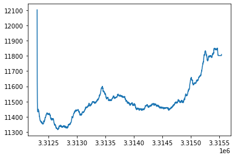

```python
import matplotlib.pyplot as plt
plt.plot(df[df['日期'] == '20200313']['發行量加權股價指數'] )
```

`2020/3/13` 美國開始有Covid-19疫情爆發，全球股市劇烈動盪的日子  
是到時敘述統計跟資料觀察很好的時間點 但我們目前還有些資料處理沒完成，得先繼續  
敬請期待`Part 3`的單日個案分析

我們將計算好的資料存db當中，方便後續直接提取。

```python
daily_RV_df.to_sql('Daily_RV', conn, if_exists = 'replace', index = None)
```

```
1560
```

```python
# 試著從db中讀取資料吧

test_df = pd.read_sql_query("SELECT * FROM Daily_RV LIMIT 10", conn)
test_df
```

|  | 日期 | daily_RV |
| --- | --- | --- |
| 0 | 20160104 | 0.497078 |
| 1 | 20160105 | 0.524352 |
| 2 | 20160106 | 0.532219 |
| 3 | 20160107 | 0.508205 |
| 4 | 20160108 | 0.530575 |
| 5 | 20160111 | 0.498361 |
| 6 | 20160112 | 0.523546 |
| 7 | 20160113 | 0.516229 |
| 8 | 20160114 | 0.607407 |
| 9 | 20160115 | 0.612971 |

## 搞定了RV之後，接著進行每日隱含波動度(Implied volatility, IV)的計算

要計算IV，我們需要的元素有以下

1. 當日的選擇權資料，我們取最近到期的option的收盤價(權利金, P)跟履約價 K
2. 當日股市的收盤價 S
3. 當日的無風險利率 r
4. 選擇權的到期日 t (須年化)

### 1. 選擇權資料

由於選擇權的**IV**被視為，*在選擇權到期日這段期間，投資人認為該標的物的波動率。*然而我們要預測的是隔一日的**RV**，故我們要盡量避免到期日不對稱的情形，也就是拿過長天期的選擇權**IV**去做短天期**RV**的預測。  
故我們以最快到期的週選擇權作為計算**IV**的標準，然而每個月的第三個禮拜三為月選擇權結算，故在第二個禮拜三當日至第三個禮拜三之間，是沒有週選擇權的，這一段期間我們則採用月選擇權來做計算。

```python
# 要來處理一下 時間 相關的變數
from datetime import datetime, timedelta
from calendar import WEDNESDAY
```

```python
# 取得該日的opt價格------------------------ ------------ ------------ ------------ ------------
# input 'date' ex: 20220524
# output 那一天的opt 日盤交易資訊 >>>df
def get_close_optData(date, conn):
    # 1. 從db中讀出該日資料------------------------------------------------
    data = pd.read_sql_query(f"SELECT * FROM TXO_option WHERE 交易日期 == '{date}' ;", conn)
    # 1.1 確認當天有無data 若無 return
    if data.empty:
        return 'DataFrame is empty'

    # 2. 找出離該日最近的option data------------------------------------------------

    # 將func input的date轉為datetime
    d_date = datetime.strptime(date, "%Y%m%d")
    data['交易日期'] = pd.to_datetime(data['交易日期'])

   # 有些同樣履約價＆契約 為日盤&夜盤2種類 >> 保留日盤資料
    data.drop_duplicates(subset = ['交易日期', '契約', '到期月份_週別', '履約價', '買賣權'], inplace = True, ignore_index = True)

    data['到期月份_週別'] = data['到期月份_週別'].astype(str)
    week_data = data[data['到期月份_週別'].str.contains(r'W')]
    mon_data = data[data['到期月份_週別'] == d_date.strftime('%Y%m')]
    # 2.1 確認交易日是否為禮拜三

    if d_date.weekday() == WEDNESDAY: #若是禮拜三
        sp = week_data['到期月份_週別'].str.extract(r'(.*)(\d)$')[1] # 取出W後面的數字
        if len(sp.unique()) == 1: #為該月的第2or第3個禮拜三
            if sp.unique() == '2':
                #若為那一週為第二個禮拜三 當日只有一種週選 但是為該週選的結算日 我們需要回傳月選
                print('該月第二個禮拜三，故找最近的月選')
                return mon_data
            else:
                print('該月第三個禮拜三，回歸週選')
                return week_data

        else: #為該月其他的禮拜三
            # 2.1.2 會有超過一種以上的 週選 應該是禮拜三 當日的結算 下週的新開
            # 故保留新開的下週 選擇W後面較大的數字
            alt_week_data = week_data[week_data['到期月份_週別'].str.contains(f'W{max(sp)}')]
            return alt_week_data

    # 若非禮拜三 才會執行下面這一段code

    if week_data.empty: # 2.1.1 沒有週選擇權資料 故找最近月的資料
        print('沒有週選擇權資料, 故找最近的月選')
        return  mon_data

    else:
        return week_data
```

我們以實際例子來看上面會回傳什麼資料，下圖為`2022/5月`的月曆

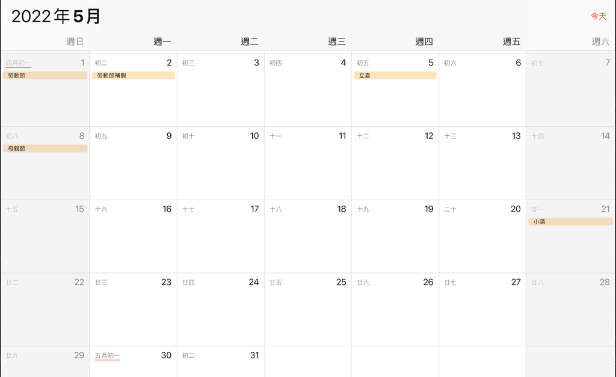

在5月的第一個禮拜三(2022/5/4)，當日會結算`202205W1`的週選，同時開啟`202205W2`的週選擇權

```python
# 順利回202205W2的週選data
test_df = get_close_optData('20220504', conn)
test_df
```

|  | 交易日期 | 契約 | 到期月份_週別 | 履約價 | 買賣權 | 開盤價 | 最高價 | 最低價 | 收盤價 | 成交量 | 結算價 | 未沖銷契約數 | 最後最佳買價 | 最後最佳賣價 | 歷史最高價 | 歷史最低價 |
| --- | --- | --- | --- | --- | --- | --- | --- | --- | --- | --- | --- | --- | --- | --- | --- | --- |
| 104 | 2022-05-04 | TXO | 202205W2 | 14800.0 | 買權 | - | - | - | - | 0 | 1740.0 | 0 | - | - | - | - |
| 105 | 2022-05-04 | TXO | 202205W2 | 14800.0 | 賣權 | 1.7 | 2.6 | 1.2 | 2.4 | 1288 | 2.4 | 914 | 1.4 | 2.4 | 2.6 | 1.2 |
| 106 | 2022-05-04 | TXO | 202205W2 | 14900.0 | 買權 | - | - | - | - | 0 | 1640.0 | 0 | - | - | - | - |
| 107 | 2022-05-04 | TXO | 202205W2 | 14900.0 | 賣權 | 1.7 | 3.3 | 1.7 | 2.9 | 32 | 2.9 | 30 | 2.6 | 2.9 | 3.3 | 1.7 |
| 108 | 2022-05-04 | TXO | 202205W2 | 15000.0 | 買權 | - | - | - | - | 0 | 1540.0 | 0 | - | - | - | - |
| ... | ... | ... | ... | ... | ... | ... | ... | ... | ... | ... | ... | ... | ... | ... | ... | ... |
| 189 | 2022-05-04 | TXO | 202205W2 | 18000.0 | 賣權 | - | - | - | - | 0 | 1460.0 | 0 | - | - | - | - |
| 190 | 2022-05-04 | TXO | 202205W2 | 18100.0 | 買權 | - | - | - | - | 0 | 0.1 | 0 | - | - | - | - |
| 191 | 2022-05-04 | TXO | 202205W2 | 18100.0 | 賣權 | - | - | - | - | 0 | 1560.0 | 0 | - | - | - | - |
| 192 | 2022-05-04 | TXO | 202205W2 | 18200.0 | 買權 | 0.1 | 0.1 | 0.1 | 0.1 | 1 | 0.1 | 1 | - | 0.4 | 0.1 | 0.1 |
| 193 | 2022-05-04 | TXO | 202205W2 | 18200.0 | 賣權 | - | - | - | - | 0 | 1660.0 | 0 | - | - | - | - |

90 rows × 16 columns

在5月的第二個禮拜三(2022/5/11)，當日為`202205W2`的週選結算，由於下個禮拜為`202205月選`結算，中間沒有週選擇權了  
故需回傳`202205的月選`資料

```python
# 順利回202205的月選data
test_df = get_close_optData('20220511', conn)
test_df
```

```
該月第二個禮拜三，故找最近的月選
```

|  | 交易日期 | 契約 | 到期月份_週別 | 履約價 | 買賣權 | 開盤價 | 最高價 | 最低價 | 收盤價 | 成交量 | 結算價 | 未沖銷契約數 | 最後最佳買價 | 最後最佳賣價 | 歷史最高價 | 歷史最低價 |
| --- | --- | --- | --- | --- | --- | --- | --- | --- | --- | --- | --- | --- | --- | --- | --- | --- |
| 114 | 2022-05-11 | TXO | 202205 | 13600.0 | 買權 | - | - | - | - | 0 | 2410.0 | 0 | - | - | - | - |
| 115 | 2022-05-11 | TXO | 202205 | 13600.0 | 賣權 | 1.3 | 1.6 | 0.6 | 1.2 | 1261 | 1.2 | 1171 | 1.0 | 1.4 | 1.9 | 0.6 |
| 116 | 2022-05-11 | TXO | 202205 | 13700.0 | 買權 | - | - | - | - | 0 | 2310.0 | 0 | - | - | - | - |
| 117 | 2022-05-11 | TXO | 202205 | 13700.0 | 賣權 | 1.3 | 1.4 | 1.3 | 1.4 | 11 | 1.4 | 11 | 1.0 | 1.4 | 1.4 | 1.3 |
| 118 | 2022-05-11 | TXO | 202205 | 13800.0 | 買權 | - | - | - | - | 0 | 2210.0 | 0 | - | - | - | - |
| ... | ... | ... | ... | ... | ... | ... | ... | ... | ... | ... | ... | ... | ... | ... | ... | ... |
| 279 | 2022-05-11 | TXO | 202205 | 20900.0 | 賣權 | - | - | - | - | 0 | 4890.0 | 0 | - | - | - | - |
| 280 | 2022-05-11 | TXO | 202205 | 21000.0 | 買權 | - | - | - | - | 0 | 0.1 | 745 | - | - | - | - |
| 281 | 2022-05-11 | TXO | 202205 | 21000.0 | 賣權 | - | - | - | - | 0 | 4990.0 | 0 | - | - | - | - |
| 282 | 2022-05-11 | TXO | 202205 | 21100.0 | 買權 | - | - | - | - | 0 | 0.1 | 6283 | - | - | - | - |
| 283 | 2022-05-11 | TXO | 202205 | 21100.0 | 賣權 | - | - | - | - | 0 | 5090.0 | 0 | - | - | - | - |

170 rows × 16 columns

在5月的第三個禮拜三(2022/5/18)，當日為`202205月選`結算，同時`202205W4`的週選開倉，故需回傳`202205W4`的週選資料

```python
# 順利回202205W4的週選data
test_df = get_close_optData('20220518', conn)
test_df
```

```
該月第三個禮拜三，回歸週選
```

|  | 交易日期 | 契約 | 到期月份_週別 | 履約價 | 買賣權 | 開盤價 | 最高價 | 最低價 | 收盤價 | 成交量 | 結算價 | 未沖銷契約數 | 最後最佳買價 | 最後最佳賣價 | 歷史最高價 | 歷史最低價 |
| --- | --- | --- | --- | --- | --- | --- | --- | --- | --- | --- | --- | --- | --- | --- | --- | --- |
| 188 | 2022-05-18 | TXO | 202205W4 | 14400.0 | 買權 | - | - | - | - | 0 | 1830.0 | 0 | - | - | - | - |
| 189 | 2022-05-18 | TXO | 202205W4 | 14400.0 | 賣權 | 1.2 | 1.7 | 0.6 | 1.0 | 294 | 1.0 | 210 | 0.6 | 1.1 | 1.7 | 0.6 |
| 190 | 2022-05-18 | TXO | 202205W4 | 14500.0 | 買權 | - | - | - | - | 0 | 1730.0 | 0 | - | - | - | - |
| 191 | 2022-05-18 | TXO | 202205W4 | 14500.0 | 賣權 | 2.0 | 2.0 | 1.5 | 1.5 | 18 | 1.5 | 18 | 0.3 | 1.6 | 2.0 | 1.5 |
| 192 | 2022-05-18 | TXO | 202205W4 | 14600.0 | 買權 | - | - | - | - | 0 | 1630.0 | 0 | - | - | - | - |
| ... | ... | ... | ... | ... | ... | ... | ... | ... | ... | ... | ... | ... | ... | ... | ... | ... |
| 269 | 2022-05-18 | TXO | 202205W4 | 17500.0 | 賣權 | - | - | - | - | 0 | 1270.0 | 0 | - | - | - | - |
| 270 | 2022-05-18 | TXO | 202205W4 | 17600.0 | 買權 | - | - | - | - | 0 | 0.1 | 0 | - | - | - | - |
| 271 | 2022-05-18 | TXO | 202205W4 | 17600.0 | 賣權 | - | - | - | - | 0 | 1370.0 | 0 | - | - | - | - |
| 272 | 2022-05-18 | TXO | 202205W4 | 17700.0 | 買權 | - | - | - | - | 0 | 0.1 | 0 | - | - | - | - |
| 273 | 2022-05-18 | TXO | 202205W4 | 17700.0 | 賣權 | - | - | - | - | 0 | 1470.0 | 0 | - | - | - | - |

86 rows × 16 columns

至於其他**非禮拜三**的時間，則是有週選回傳週選，沒有週選擇回傳月選  
以5/12(只有月選)跟5/19(有週選)作為示範

```python
# 只有月選
test_df = get_close_optData('20220512', conn)
test_df
```

```
沒有週選擇權資料, 故找最近的月選
```

|  | 交易日期 | 契約 | 到期月份_週別 | 履約價 | 買賣權 | 開盤價 | 最高價 | 最低價 | 收盤價 | 成交量 | 結算價 | 未沖銷契約數 | 最後最佳買價 | 最後最佳賣價 | 歷史最高價 | 歷史最低價 |
| --- | --- | --- | --- | --- | --- | --- | --- | --- | --- | --- | --- | --- | --- | --- | --- | --- |
| 0 | 2022-05-12 | TXO | 202205 | 13600.0 | 買權 | - | - | - | - | 0 | 2030.0 | 0 | - | - | - | - |
| 1 | 2022-05-12 | TXO | 202205 | 13600.0 | 賣權 | 1.2 | 2.0 | 0.4 | 2.0 | 447 | 2.0 | 1432 | 1.7 | 2.1 | 2.1 | 0.4 |
| 2 | 2022-05-12 | TXO | 202205 | 13700.0 | 買權 | - | - | - | - | 0 | 1930.0 | 0 | - | - | - | - |
| 3 | 2022-05-12 | TXO | 202205 | 13700.0 | 賣權 | 1.3 | 2.5 | 1.0 | 2.2 | 64 | 2.2 | 95 | 1.0 | 2.5 | 2.5 | 1.0 |
| 4 | 2022-05-12 | TXO | 202205 | 13800.0 | 買權 | - | - | - | - | 0 | 1830.0 | 0 | - | - | - | - |
| ... | ... | ... | ... | ... | ... | ... | ... | ... | ... | ... | ... | ... | ... | ... | ... | ... |
| 167 | 2022-05-12 | TXO | 202205 | 20900.0 | 賣權 | - | - | - | - | 0 | 5270.0 | 0 | - | - | - | - |
| 168 | 2022-05-12 | TXO | 202205 | 21000.0 | 買權 | - | - | - | - | 0 | 0.1 | 745 | - | - | - | - |
| 169 | 2022-05-12 | TXO | 202205 | 21000.0 | 賣權 | - | - | - | - | 0 | 5370.0 | 0 | - | - | - | - |
| 170 | 2022-05-12 | TXO | 202205 | 21100.0 | 買權 | 0.1 | 0.6 | 0.1 | 0.1 | 24 | 0.1 | 6287 | - | 0.4 | 10.0 | 0.1 |
| 171 | 2022-05-12 | TXO | 202205 | 21100.0 | 賣權 | - | - | - | - | 0 | 5470.0 | 0 | - | - | - | - |

172 rows × 16 columns

```python
# 有週選
test_df = get_close_optData('20220519', conn)
test_df
```

|  | 交易日期 | 契約 | 到期月份_週別 | 履約價 | 買賣權 | 開盤價 | 最高價 | 最低價 | 收盤價 | 成交量 | 結算價 | 未沖銷契約數 | 最後最佳買價 | 最後最佳賣價 | 歷史最高價 | 歷史最低價 |
| --- | --- | --- | --- | --- | --- | --- | --- | --- | --- | --- | --- | --- | --- | --- | --- | --- |
| 0 | 2022-05-19 | TXO | 202205W4 | 14400.0 | 買權 | - | - | - | - | 0 | 1560.0 | 0 | - | - | - | - |
| 1 | 2022-05-19 | TXO | 202205W4 | 14400.0 | 賣權 | 4.0 | 4.5 | 1.7 | 2.4 | 4047 | 2.4 | 3731 | 2.2 | 2.5 | 4.8 | 0.6 |
| 2 | 2022-05-19 | TXO | 202205W4 | 14500.0 | 買權 | - | - | - | - | 0 | 1460.0 | 0 | - | - | - | - |
| 3 | 2022-05-19 | TXO | 202205W4 | 14500.0 | 賣權 | 6.0 | 6.0 | 2.0 | 3.0 | 1213 | 3.0 | 788 | 2.0 | 3.8 | 6.0 | 0.9 |
| 4 | 2022-05-19 | TXO | 202205W4 | 14600.0 | 買權 | - | - | - | - | 0 | 1360.0 | 0 | - | - | - | - |
| ... | ... | ... | ... | ... | ... | ... | ... | ... | ... | ... | ... | ... | ... | ... | ... | ... |
| 93 | 2022-05-19 | TXO | 202205W4 | 17800.0 | 賣權 | - | - | - | - | 0 | 1850.0 | 0 | - | - | - | - |
| 94 | 2022-05-19 | TXO | 202205W4 | 17900.0 | 買權 | - | - | - | - | 0 | 0.1 | 0 | - | - | - | - |
| 95 | 2022-05-19 | TXO | 202205W4 | 17900.0 | 賣權 | - | - | - | - | 0 | 1950.0 | 0 | - | - | - | - |
| 96 | 2022-05-19 | TXO | 202205W4 | 18000.0 | 買權 | 0.5 | 0.5 | 0.5 | 0.5 | 2 | 0.1 | 2 | 0.1 | 0.6 | 0.5 | 0.5 |
| 97 | 2022-05-19 | TXO | 202205W4 | 18000.0 | 賣權 | - | - | - | - | 0 | 2050.0 | 0 | - | - | - | - |

98 rows × 16 columns

### 計算IV，需要的輸入資料

1. [x] 當日的選擇權資料，我們取最近到期的option的收盤價(權利金, **P**)跟履約價**K**
2. [ ] 當日股市的收盤價**S**
3. [ ] 當日的無風險利**r**
4. [ ] 選擇權的到期日**t** (須年化)

故`get_close_optData`搞定了我們需要的option權利金**P**跟履約收盤價**K**  
接下來我們要找出該日的大盤收盤價

先從db中的`TAIEX_index table`中找出該日的收盤價，這會回傳3241個資料(5秒日內)  
我們要的收盤價為該series最後一格

```python
df = pd.read_sql_query("SELECT * FROM TAIEX_index WHERE 日期 = '20220519' ;", conn)
df
```

|  | 日期 | 時間 | 發行量加權股價指數 |
| --- | --- | --- | --- |
| 0 | 20220519 | 09:00:00 | 16,296.86 |
| 1 | 20220519 | 09:00:05 | 16,111.49 |
| 2 | 20220519 | 09:00:10 | 16,047.54 |
| 3 | 20220519 | 09:00:15 | 15,975.58 |
| 4 | 20220519 | 09:00:20 | 15,952.44 |
| ... | ... | ... | ... |
| 3236 | 20220519 | 13:29:40 | 16,026.29 |
| 3237 | 20220519 | 13:29:45 | 16,026.29 |
| 3238 | 20220519 | 13:29:50 | 16,026.29 |
| 3239 | 20220519 | 13:29:55 | 16,026.29 |
| 3240 | 20220519 | 13:30:00 | 16,020.32 |

3241 rows × 3 columns

```python
closed_price = df['發行量加權股價指數'].iloc[-1]
closed_price
```

```
'16,020.32'
```

```python
# 將其轉換成float
closed_price = float(closed_price.replace(',',''))
closed_price
```

```
16020.32
```

```python
# 包在function中
def get_daily_close_TAIEX(day, conn):
    df = pd.read_sql_query(f"SELECT * FROM TAIEX_index WHERE 日期 = {day} ;", conn)
    closed_price = float(df['發行量加權股價指數'].iloc[-1].replace(',',''))
    return closed_price
```

```python
#假設想找出2022/5/23的收盤價
print(get_daily_close_TAIEX('20220519', conn))
```

```
16020.32
```

### 計算IV，需要的輸入資料

1. [x] 當日的選擇權資料，我們取最近到期的option的收盤價(權利金, **P**)跟履約價**K**
2. [x] 當日股市的收盤價**S**
3. [ ] 當日的無風險利**r**
4. [ ] 選擇權的到期日**t** (須年化)

無風險利率是儲存在db中的`interest_rate_table`這個table裡  
如同收盤價的方式讀取資料。  
這邊我就直接寫成function並輸出結果吧

```python
def get_Risk_free_IR(day, conn):
    df = pd.read_sql_query(f"SELECT * FROM interest_rate_table WHERE 日期 = {day} ;", conn)
    # 在原始資料中的資單位為% 故除100回到float
    interest_rate = float(df['利率'].iloc[0]) / 100
    return interest_rate
```

```python
#假設想找出2022/5/23的無風險利率
print(get_Risk_free_IR('20220519', conn))
```

```
0.00181
```

### 計算IV，需要的輸入資料

1. [x] 當日的選擇權資料，我們取最近到期的option的收盤價(權利金, **P**)跟履約價**K**
2. [x] 當日股市的收盤價**S**
3. [x] 當日的無風險利**r**
4. [ ] 選擇權的到期日**t** (須年化)

最後一項比較tricky  
我們在處理**回傳選擇權的收盤價跟履約價時**，設計是找出該交易日中**最快到期的選擇權**，  
又每個禮拜三都會有選擇權到期，我們可以直覺想成，該交易日離下禮拜三，還有幾個交易日(weekday)。

另一種思路是直接從既有的資料中去找尋該選擇權的結束日期，可是在面對全新的資料，例如下禮拜才到期的選擇權，你的資料庫裡一定不會有該選擇權的全部資料，故我們用這個方式去推估，雖然不可避免在少部分國定假日之類的，使到期時間高估，但整個區間的誤差非常小，且不頻繁。

### 一樣拿2022/5月的行事曆做比對

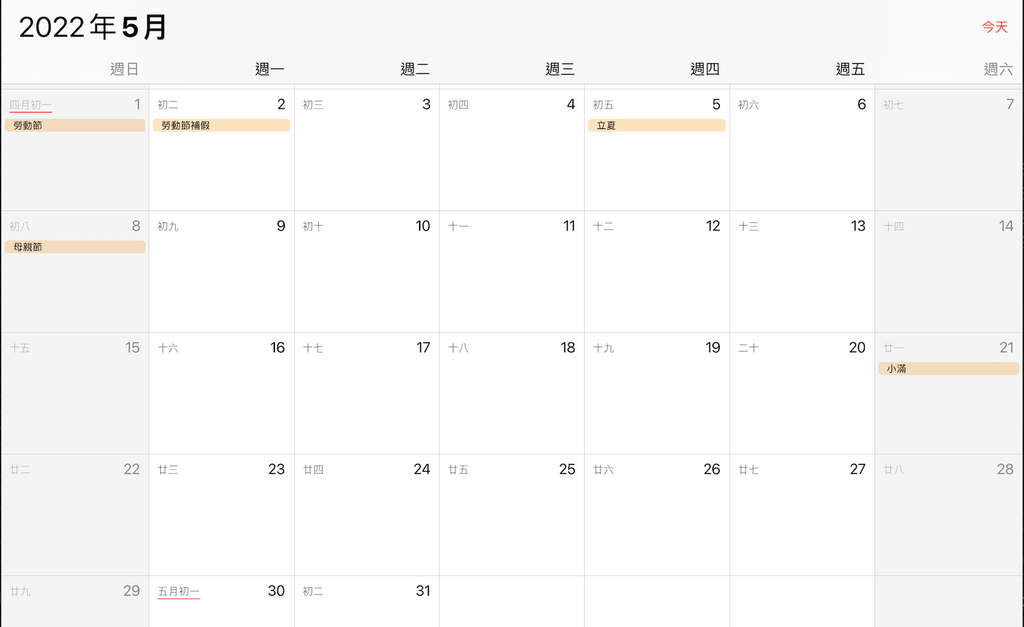

```python
# 日期測試
cal_date = datetime(2022, 5, 4)
cal_date
```

```
datetime.datetime(2022, 5, 4, 0, 0)
```

```python
# cal_date -> 我們想要計算IV的特定交易日
# due_date -> 最近的option的到期日
if cal_date.weekday() < WEDNESDAY: # 特定交易日 為禮拜一or二 故到期日也是'那個'禮拜三
    delta = WEDNESDAY - cal_date.weekday()
    due_date = cal_date + timedelta(days=delta)
    print(f'{due_date = }')
    print('剩餘天數：' ,due_date.weekday() - cal_date.weekday())

elif cal_date.weekday() >= WEDNESDAY: # 特定交易日 為禮拜三四五 故到期日是'下個'禮拜三 +5
    delta = cal_date.weekday() - WEDNESDAY
    due_date = cal_date + timedelta(days=(7 - delta))
    print(f'{due_date = }')
    print('剩餘天數：' ,due_date.weekday() - cal_date.weekday() + 5 )
```

```
due_date = datetime.datetime(2022, 5, 11, 0, 0)
剩餘天數： 5
```

可以看到`2022/5/4`日所發售的`202205W2`選擇權，他選擇權到期的時間是`2022/5/11`，中間還有`5`個交易日剩餘

```python
# 包成function
# input datetime
# return 到期日datetime, 剩餘天數
def get_due_date(cal_date):

    cal_date = datetime.strptime(cal_date, '%Y%m%d')
    if cal_date.weekday() < WEDNESDAY: # 特定交易日 為禮拜一or二 故到期日也是'那個'禮拜三
        delta = WEDNESDAY - cal_date.weekday()
        due_date = cal_date + timedelta(days=delta)
        due_date_delta = due_date.weekday() - cal_date.weekday()

    elif cal_date.weekday() >= WEDNESDAY: # 特定交易日 為禮拜三四五 故到期日是'下個'禮拜三 +5
        delta = cal_date.weekday() - WEDNESDAY
        due_date = cal_date + timedelta(days=(7 - delta))
        due_date_delta = due_date.weekday() - cal_date.weekday() + 5

    return due_date, due_date_delta
```

```python
# 第一個是回傳選擇權的到期日
# 第二個是回傳選擇權的剩餘天數
cal_date = '20220507' #我們的時間輸入統一為 YYYYMMDD

print(get_due_date(cal_date))
```

```
(datetime.datetime(2022, 5, 11, 0, 0), 2)
```

## 終於！我們就像是薩諾斯收集齊了無限寶石般，準備好所有要計算IV的必要資料了！

> 1. [x] 當日的選擇權資料，我們取最近到期的option的收盤價(權利金, P)跟履約價 K
> 2. [x] 當日股市的收盤價 S
> 3. [x] 當日的無風險利率 r
> 4. [x] 選擇權的到期日 t (須年化)

### 再來就是將這些資料輸入，去計算是該日的個選擇權IV

我們採用的套件為 [py_vollib_vectorized](https://py-vollib-vectorized.readthedocs.io/en/latest/)(連結為其documentation)  
將選擇權的權利金以及履約價資料以向量化的方式做運算，使我們可以同時計算多個選擇權的IV

### 就用2022/5/4示範計算

```python
date =  '20220504'
```

```python
# 選擇權資料
opt_data = get_close_optData(date, conn)
opt_data
```

|  | 交易日期 | 契約 | 到期月份_週別 | 履約價 | 買賣權 | 開盤價 | 最高價 | 最低價 | 收盤價 | 成交量 | 結算價 | 未沖銷契約數 | 最後最佳買價 | 最後最佳賣價 | 歷史最高價 | 歷史最低價 |
| --- | --- | --- | --- | --- | --- | --- | --- | --- | --- | --- | --- | --- | --- | --- | --- | --- |
| 104 | 2022-05-04 | TXO | 202205W2 | 14800.0 | 買權 | - | - | - | - | 0 | 1740.0 | 0 | - | - | - | - |
| 105 | 2022-05-04 | TXO | 202205W2 | 14800.0 | 賣權 | 1.7 | 2.6 | 1.2 | 2.4 | 1288 | 2.4 | 914 | 1.4 | 2.4 | 2.6 | 1.2 |
| 106 | 2022-05-04 | TXO | 202205W2 | 14900.0 | 買權 | - | - | - | - | 0 | 1640.0 | 0 | - | - | - | - |
| 107 | 2022-05-04 | TXO | 202205W2 | 14900.0 | 賣權 | 1.7 | 3.3 | 1.7 | 2.9 | 32 | 2.9 | 30 | 2.6 | 2.9 | 3.3 | 1.7 |
| 108 | 2022-05-04 | TXO | 202205W2 | 15000.0 | 買權 | - | - | - | - | 0 | 1540.0 | 0 | - | - | - | - |
| ... | ... | ... | ... | ... | ... | ... | ... | ... | ... | ... | ... | ... | ... | ... | ... | ... |
| 189 | 2022-05-04 | TXO | 202205W2 | 18000.0 | 賣權 | - | - | - | - | 0 | 1460.0 | 0 | - | - | - | - |
| 190 | 2022-05-04 | TXO | 202205W2 | 18100.0 | 買權 | - | - | - | - | 0 | 0.1 | 0 | - | - | - | - |
| 191 | 2022-05-04 | TXO | 202205W2 | 18100.0 | 賣權 | - | - | - | - | 0 | 1560.0 | 0 | - | - | - | - |
| 192 | 2022-05-04 | TXO | 202205W2 | 18200.0 | 買權 | 0.1 | 0.1 | 0.1 | 0.1 | 1 | 0.1 | 1 | - | 0.4 | 0.1 | 0.1 |
| 193 | 2022-05-04 | TXO | 202205W2 | 18200.0 | 賣權 | - | - | - | - | 0 | 1660.0 | 0 | - | - | - | - |

90 rows × 16 columns

### 1. 我們只需要'買權'的履約價以及收盤價，且排除交易量為0的選擇權

尤其像`2022/5/4`禮拜三開新的週選擇權，**交易量為0**的選擇權將沒有收盤價。

```python
opt_data = opt_data[opt_data['買賣權'] == '買權']
opt_data = opt_data[~(opt_data['成交量'] == 0)]
opt_data[['交易日期','到期月份_週別','買賣權','履約價','收盤價']]
```

|  | 交易日期 | 到期月份_週別 | 買賣權 | 履約價 | 收盤價 |
| --- | --- | --- | --- | --- | --- |
| 124 | 2022-05-04 | 202205W2 | 買權 | 15800.0 | 760.0 |
| 128 | 2022-05-04 | 202205W2 | 買權 | 16000.0 | 580.0 |
| 130 | 2022-05-04 | 202205W2 | 買權 | 16050.0 | 535.0 |
| 132 | 2022-05-04 | 202205W2 | 買權 | 16100.0 | 488.0 |
| 134 | 2022-05-04 | 202205W2 | 買權 | 16150.0 | 449.0 |
| 136 | 2022-05-04 | 202205W2 | 買權 | 16200.0 | 415.0 |
| 138 | 2022-05-04 | 202205W2 | 買權 | 16250.0 | 370.0 |
| 140 | 2022-05-04 | 202205W2 | 買權 | 16300.0 | 330.0 |
| 142 | 2022-05-04 | 202205W2 | 買權 | 16350.0 | 302.0 |
| 144 | 2022-05-04 | 202205W2 | 買權 | 16400.0 | 260.0 |
| 146 | 2022-05-04 | 202205W2 | 買權 | 16450.0 | 229.0 |
| 148 | 2022-05-04 | 202205W2 | 買權 | 16500.0 | 196.0 |
| 150 | 2022-05-04 | 202205W2 | 買權 | 16550.0 | 171.0 |
| 152 | 2022-05-04 | 202205W2 | 買權 | 16600.0 | 143.0 |
| 154 | 2022-05-04 | 202205W2 | 買權 | 16650.0 | 120.0 |
| 156 | 2022-05-04 | 202205W2 | 買權 | 16700.0 | 98.0 |
| 158 | 2022-05-04 | 202205W2 | 買權 | 16750.0 | 78.0 |
| 160 | 2022-05-04 | 202205W2 | 買權 | 16800.0 | 60.0 |
| 162 | 2022-05-04 | 202205W2 | 買權 | 16850.0 | 45.5 |
| 164 | 2022-05-04 | 202205W2 | 買權 | 16900.0 | 32.5 |
| 166 | 2022-05-04 | 202205W2 | 買權 | 16950.0 | 22.0 |
| 168 | 2022-05-04 | 202205W2 | 買權 | 17000.0 | 15.5 |
| 170 | 2022-05-04 | 202205W2 | 買權 | 17100.0 | 7.2 |
| 172 | 2022-05-04 | 202205W2 | 買權 | 17200.0 | 3.1 |
| 174 | 2022-05-04 | 202205W2 | 買權 | 17300.0 | 2.0 |
| 176 | 2022-05-04 | 202205W2 | 買權 | 17400.0 | 1.0 |
| 178 | 2022-05-04 | 202205W2 | 買權 | 17500.0 | 1.0 |
| 180 | 2022-05-04 | 202205W2 | 買權 | 17600.0 | 1.5 |
| 182 | 2022-05-04 | 202205W2 | 買權 | 17700.0 | 0.6 |
| 184 | 2022-05-04 | 202205W2 | 買權 | 17800.0 | 1.9 |
| 192 | 2022-05-04 | 202205W2 | 買權 | 18200.0 | 0.1 |

### 2. 該日的大盤收盤價、無風險利率以及到期的剩餘時間

```python
closed_price = get_daily_close_TAIEX(date, conn)
print(f'{date}的收盤價：{closed_price}')
```

```
20220504的收盤價：16565.83
```

```python
IR = get_Risk_free_IR(date, conn)
print(f'{date}的無風險利率：{IR}')
```

```
20220504的無風險利率：0.00181
```

```python
opt_due_day = get_due_date(date)[1]
print(f'{date}選擇權的剩餘天數：{opt_due_day}')
```

```
20220504選擇權的剩餘天數：5
```

### 3. 將上述資料丟進py_vollib_vectorized的function中做計算

```python
import py_vollib_vectorized
```

```python
price = opt_data['收盤價'] # 權利金 也就是選擇權的收盤價
S = closed_price # 台股當時指數
K = opt_data['履約價'] # 選擇權的履約價格 N個
t = opt_due_day / 252 # 到期期間 單為：年 故除上252個交易日
r = IR # 無風險利率
flag = ['c'] # 我們這次計算的是買權
opt_data['IV'] = py_vollib_vectorized.vectorized_implied_volatility(price, S, K, t, r, flag, q=0, model='black_scholes_merton',return_as='numpy')  # equivalent
```

```python
# 檢視一下運算狀況
pd.set_option('display.max_rows', None)
```

```python
opt_data[['交易日期','到期月份_週別','買賣權','履約價','收盤價','成交量', 'IV']]
```

|  | 交易日期 | 到期月份_週別 | 買賣權 | 履約價 | 收盤價 | 成交量 | IV |
| --- | --- | --- | --- | --- | --- | --- | --- |
| 124 | 2022-05-04 | 202205W2 | 買權 | 15800.0 | 760.0 | 2 | NaN |
| 128 | 2022-05-04 | 202205W2 | 買權 | 16000.0 | 580.0 | 9 | 0.172732 |
| 130 | 2022-05-04 | 202205W2 | 買權 | 16050.0 | 535.0 | 13 | 0.174233 |
| 132 | 2022-05-04 | 202205W2 | 買權 | 16100.0 | 488.0 | 4 | 0.168481 |
| 134 | 2022-05-04 | 202205W2 | 買權 | 16150.0 | 449.0 | 2 | 0.176925 |
| 136 | 2022-05-04 | 202205W2 | 買權 | 16200.0 | 415.0 | 38 | 0.188653 |
| 138 | 2022-05-04 | 202205W2 | 買權 | 16250.0 | 370.0 | 17 | 0.180027 |
| 140 | 2022-05-04 | 202205W2 | 買權 | 16300.0 | 330.0 | 94 | 0.176951 |
| 142 | 2022-05-04 | 202205W2 | 買權 | 16350.0 | 302.0 | 146 | 0.186682 |
| 144 | 2022-05-04 | 202205W2 | 買權 | 16400.0 | 260.0 | 130 | 0.176519 |
| 146 | 2022-05-04 | 202205W2 | 買權 | 16450.0 | 229.0 | 214 | 0.177086 |
| 148 | 2022-05-04 | 202205W2 | 買權 | 16500.0 | 196.0 | 718 | 0.172879 |
| 150 | 2022-05-04 | 202205W2 | 買權 | 16550.0 | 171.0 | 707 | 0.174819 |
| 152 | 2022-05-04 | 202205W2 | 買權 | 16600.0 | 143.0 | 1912 | 0.170872 |
| 154 | 2022-05-04 | 202205W2 | 買權 | 16650.0 | 120.0 | 1286 | 0.169612 |
| 156 | 2022-05-04 | 202205W2 | 買權 | 16700.0 | 98.0 | 3179 | 0.166651 |
| 158 | 2022-05-04 | 202205W2 | 買權 | 16750.0 | 78.0 | 2019 | 0.162957 |
| 160 | 2022-05-04 | 202205W2 | 買權 | 16800.0 | 60.0 | 4962 | 0.158374 |
| 162 | 2022-05-04 | 202205W2 | 買權 | 16850.0 | 45.5 | 2177 | 0.154825 |
| 164 | 2022-05-04 | 202205W2 | 買權 | 16900.0 | 32.5 | 3716 | 0.149569 |
| 166 | 2022-05-04 | 202205W2 | 買權 | 16950.0 | 22.0 | 4848 | 0.143923 |
| 168 | 2022-05-04 | 202205W2 | 買權 | 17000.0 | 15.5 | 4221 | 0.141865 |
| 170 | 2022-05-04 | 202205W2 | 買權 | 17100.0 | 7.2 | 3269 | 0.138524 |
| 172 | 2022-05-04 | 202205W2 | 買權 | 17200.0 | 3.1 | 2621 | 0.136280 |
| 174 | 2022-05-04 | 202205W2 | 買權 | 17300.0 | 2.0 | 299 | 0.143907 |
| 176 | 2022-05-04 | 202205W2 | 買權 | 17400.0 | 1.0 | 531 | 0.146229 |
| 178 | 2022-05-04 | 202205W2 | 買權 | 17500.0 | 1.0 | 90 | 0.161067 |
| 180 | 2022-05-04 | 202205W2 | 買權 | 17600.0 | 1.5 | 6 | 0.184610 |
| 182 | 2022-05-04 | 202205W2 | 買權 | 17700.0 | 0.6 | 212 | 0.179535 |
| 184 | 2022-05-04 | 202205W2 | 買權 | 17800.0 | 1.9 | 4 | 0.220752 |
| 192 | 2022-05-04 | 202205W2 | 買權 | 18200.0 | 0.1 | 1 | 0.209557 |

### 計算完成了！但我們需要驗算一下

- 履約價：16700
- 收盤價：98
- 收盤價：16565.83
- 無風險利率：0.00181
- 剩餘天數：0.01984年 (5/252)

我們用code計算出來的**IV**為`0.166651`

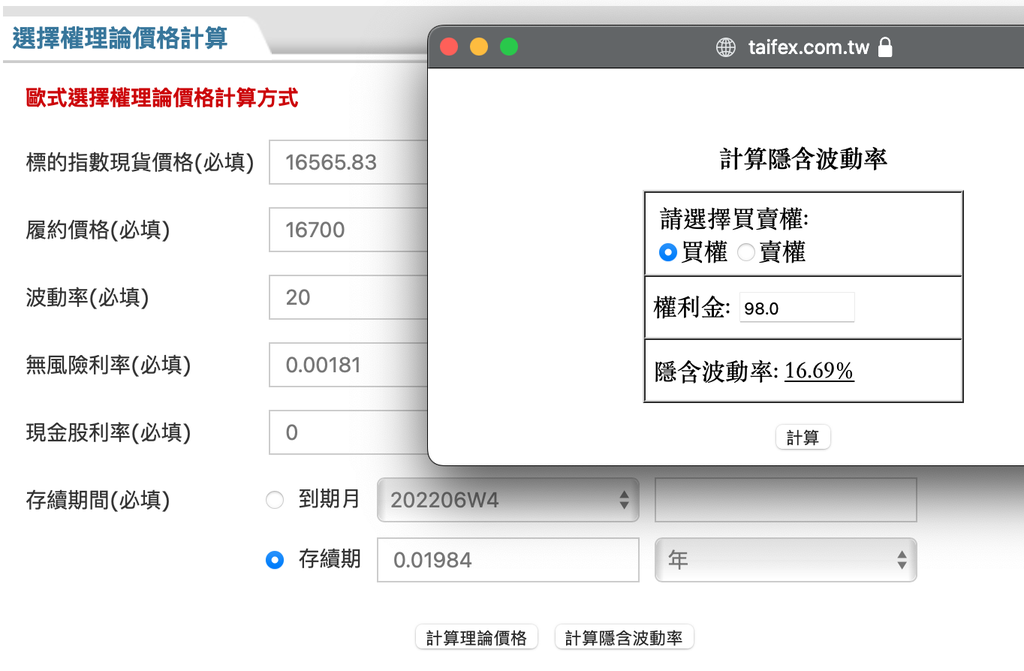

看來我們計算的結果與期貨交易所試算的結果相同，其中誤差可視為是浮點位數計算問題。  
**故我們的IV計算大獲成功!**  
然而這還不是結束，我們還要將**IV**做些轉換成為DL模型的輸入，但在這之前，我們先來進行單日的個案探討與圖表分析吧。記得點選連結是**Part 3**!

### 附錄 : 製作function集

為了方便後續重複使用這些function，我將`get_close_optData, get_daily_RV, get_close_optData, get_daily_close_TAIEX, get_vector_IV`包成一個function集，並將該script命名為`get_data_db.py`，之後直接import該script，就可以直接使用。

```python
import pandas as pd
import sqlite3
import numpy as np
from datetime import datetime
import py_vollib_vectorized
from calendar import WEDNESDAY



# 計算該日大盤的RV---------------------------------------------------------------------------
# input 'date' ex: 20220524
# output 那一天的RV >>>float
def get_daily_RV(day, conn):
    df = pd.read_sql_query(f"SELECT * FROM TAIEX_index WHERE 日期 = {day} ;", conn)
    if not df.empty:
        df['發行量加權股價指數'] = df['發行量加權股價指數'].str.replace(',','').astype(float)
        # ln(dt/dt-1) = ln(dt) - ln(dt-1)
        df['log_return'] = np.log(df['發行量加權股價指數']) - np.log(df['發行量加權股價指數'].shift(1))
        RV = np.sqrt( (1 / len(df['log_return'])) * (np.sum(df['log_return'] ** 2))) * 252
        return RV
    else:
        return 'empty df'

# 取得該日的opt價格------------------------ ------------ ------------ ------------ ------------
# input 'date' ex: 20220524
# output 那一天的opt 日盤交易資訊 >>>df
def get_close_optData(date, conn):
    # 1. 從db中讀出該日資料------------------------------------------------
    data = pd.read_sql_query(f"SELECT * FROM TXO_option WHERE 交易日期 == '{date}' ;", conn)
    # 1.1 確認當天有無data 若無 return
    if data.empty:
        return 'DataFrame is empty'

    # 2. 找出離該日最近的option data------------------------------------------------

    # 將func input的date轉為datetime
    d_date = datetime.strptime(date, "%Y%m%d")
    data['交易日期'] = pd.to_datetime(data['交易日期'])

   # 有些同樣履約價＆契約 為日盤&夜盤2種類 >> 保留日盤資料
    data.drop_duplicates(subset = ['交易日期', '契約', '到期月份_週別', '履約價', '買賣權'], inplace = True, ignore_index = True)

    data['到期月份_週別'] = data['到期月份_週別'].astype(str)
    week_data = data[data['到期月份_週別'].str.contains(r'W')]
    mon_data = data[data['到期月份_週別'] == d_date.strftime('%Y%m')]
    # 2.1 確認交易日是否為禮拜三

    if d_date.weekday() == WEDNESDAY: #若是禮拜三
        sp = week_data['到期月份_週別'].str.extract(r'(.*)(\d)$')[1] # 取出W後面的數字
        if len(sp.unique()) == 1: #為該月的第2or第3個禮拜三
            if sp.unique() == '2':
                #若為那一週為第二個禮拜三 當日只有一種週選 但是為該週選的結算日 我們需要回傳月選
                print('該月第二個禮拜三，故找最近的月選')
                return mon_data
            else:
                print('該月第三個禮拜三，回歸週選')
                return week_data

        else: #為該月其他的禮拜三
            # 2.1.2 會有超過一種以上的 週選 應該是禮拜三 當日的結算 下週的新開
            # 故保留新開的下週 選擇W後面較大的數字
            alt_week_data = week_data[week_data['到期月份_週別'].str.contains(f'W{max(sp)}')]
            return alt_week_data

    # 若非禮拜三 才會執行下面這一段code

    if week_data.empty: # 2.1.1 沒有週選擇權資料 故找最近月的資料
        print('沒有週選擇權資料, 故找最近的月選')
        return  mon_data

    else:
        return week_data




# 只出現月選版本
def get_close_optData_mon_only(date, conn):
    # 1. 從db中讀出該日資料------------------------------------------------
    data = pd.read_sql_query(f"SELECT * FROM TXO_option WHERE 交易日期 == '{date}' ;", conn)
    # 1.1 確認當天有無data 若無 return
    if data.empty:
        return 'DataFrame is empty'

    # 2. 找出離該日最近的option data------------------------------------------------

    # 將func input的date轉為datetime
    d_date = datetime.strptime(date, "%Y%m%d")
    data['交易日期'] = pd.to_datetime(data['交易日期'])

   # 有些同樣履約價＆契約 為日盤&夜盤2種類 >> 保留日盤資料
    data.drop_duplicates(subset = ['交易日期', '契約', '到期月份_週別', '履約價', '買賣權'], inplace = True, ignore_index = True)
    data['到期月份_週別'] = data['到期月份_週別'].astype(str)

    mon_data = data[data['到期月份_週別'] == d_date.strftime('%Y%m')]

    return  mon_data



# 取得該日的大盤收盤價------------------------ ------------ ------------ ------------ ------------
# input 'date' ex: 20220524
# output 那一天的大盤收盤價 >>> float
def get_daily_close_TAIEX(day, conn):
    df = pd.read_sql_query(f"SELECT * FROM TAIEX_index WHERE 日期 = {day} ;", conn)
    close_price = float(df['發行量加權股價指數'].iloc[-1].replace(',',''))
    return close_price

# 取得該日的無風險利率------------------------ ------------ ------------ ------------ ------------
def get_Risk_free_IR(day, conn):
    df = pd.read_sql_query(f"SELECT * FROM interest_rate_table WHERE 日期 = {day} ;", conn)
    interest_rate = float(df['利率'].iloc[0]) / 100
    return interest_rate

# 取得該日的opt IV------------------------ ------------ ------------ ------------ ------------
# input opt_df(from get_close_optData's output), 大盤收盤價(from get_daily_close_TAIEX's output)
# output 那一天的opt data with IV >>>df
# t 跟 r 尚未處理完畢
def get_vector_IV(df, TAIEX_close_price, due_day, IR):
    opt_df = df[df['買賣權'] == '買權']
    # 將成交量為0的去除
    opt_df =  opt_df[~(opt_df['成交量'] == 0)]
    price = opt_df['收盤價'] # 權利金 也就是選擇權的收盤價
    S = TAIEX_close_price # 台股當時指數
    K = opt_df['履約價']
    t = due_day / 252 # 轉換成年 用交易日252日
    r = IR # 無風險利率
    flag = ['c']
    opt_df['IV'] = py_vollib_vectorized.vectorized_implied_volatility(price, S, K, t, r, flag, q=0, model='black_scholes_merton',return_as='numpy')  # equivalent

    return opt_df
```